# Single layer measurements

Joan Ginard

13 de junio, 2023

```r
library(igraph)
library(tidyverse)
library(patchwork)


source("helper_functions.R")
source("GraphMeasurementFunctions.R")
```

In this R markdown file, we will execute necessary steps to apply single-layer graph measures to our data.

In fact, we will create two equal R markdown files. This one operates normalizing the matrices, while the other without normalization.

To incorporate multilayer measures, we must obtain single-layer graph measures from normalized ones.

As in processing step we will use functions defined in “helper_functions.R”. We will also use functions defined in “GraphMeasurementFunctions.R”

# LOAD DATA

```r
#Folders
dataDIR <- "data/"
FADIR <- "FA_matrices_harm/"
GMDIR <- "GM_matrices_c/"
fMRIDIR <- "fMRI_matrices_c/"

### clinical data

clinic_file <- "clinic.csv"


### vertex names
names_file <- "mindboggle_ROIs.txt"
```

## Load clinical data

```r
clinical_data <- read.csv(file.path(dataDIR, clinic_file))[, -1] #with -1 we avoid loading index column

clinical_data <- clinical_data[order(clinical_data$id),] #order by id, though not necessay we enforce it
```

#### CREATE LABELS

```r
clinical_data$controls_ms <- factor(clinical_data$controls_ms,
                                    levels = c(0,1),
                                    labels = c("HS", "PwMS"))
clinical_data$sex <- factor(clinical_data$sex,
                            levels = c(0,1),
                            labels = c("Female", "Male"))
clinical_data$mstype <- factor(clinical_data$mstype,
                               levels = c(-1, 0, 1, 2),
                               labels = c("HS", "RRMS", "SPMS", "PPMS"))
```

## Load vertex names

```r
vertex_names <- read.table(file.path(dataDIR, names_file), skip = 1)[, 2]
```

## Load graphs with svd normalization

If we aim to ‘integrate’ all layers into a single multi-layer measurement, it is essential to normalize the weights so they can be merged into a singular network. We will apply SVD normalization, as elucidated in Mandke, Meier et al. (2018). It is also interesting to point out it also used in Pontillo, Prados et al. 2022.

```r
FA_graphs <- load_graphs(FADIR, clinical_data, normalization = TRUE)
```

```
## [1] "CORRECT. SAME ORDER"
```

```r
GM_graphs <- load_graphs(GMDIR, clinical_data, normalization = TRUE)
```

```
## [1] "CORRECT. SAME ORDER"
```

```r
fMRI_graphs <- load_graphs(fMRIDIR, clinical_data, normalization = TRUE)
```

```
## [1] "CORRECT. SAME ORDER"
```

# GLOBAL Graph basic measurements

We are measuring for each graph and each layer the following measures:

1. Global Efficiency
2. Mean Path Length
3. Transitivity, global clustering
4. Diameter
5. Modularity
6. Global Strength
7. Density

```r
clinical_data <- add_global_graph_measures(clinical_data, FA_graphs, "FA")
clinical_data <- add_global_graph_measures(clinical_data, GM_graphs, "GM")
clinical_data <- add_global_graph_measures(clinical_data, fMRI_graphs, "fMRI")
```

We create a dataframe to summarise values. Later we will add p values

```r
#Preserve only numerical values
df_temp <- cbind(clinical_data[, "controls_ms"], clinical_data[, 27:ncol(clinical_data)])
colnames(df_temp)[1] <- "controls_ms"

df_summary <- data.frame(measurement = character(0),
                          Mean_HS = numeric(0),
                         sd_HS = numeric(0),
                         Mean_PWMS = numeric(0),
                         sd_PWMS = numeric(0))

for(i in 2:ncol(df_temp)){
  measurement <- colnames(df_temp)[i]
  Mean_HS <- mean(df_temp[df_temp$controls_ms == "HS", i])
  sd_HS <- sd(df_temp[df_temp$controls_ms == "HS", i])

  Mean_PWMS <- mean(df_temp[df_temp$controls_ms == "PwMS", i])
  sd_PWMS <- sd(df_temp[df_temp$controls_ms == "PwMS", i])

  df_summary <- rbind( df_summary, data.frame(measurement = measurement,
                                              Mean_HS = Mean_HS,
                                              sd_HS = sd_HS,
                                              Mean_PWMS = Mean_PWMS,
                                              sd_PWMS = sd_PWMS))

}

head(df_summary)
```

```
##           measurement   Mean_HS      sd_HS Mean_PWMS    sd_PWMS
## 1         FA_diameter 0.3322241 0.03432373 0.3141971 0.03636324
## 2    FA_gl-efficiency 6.2664203 0.99438707 6.4091196 0.92026621
## 3 FA_mean_path-length 0.1782653 0.02398921 0.1736762 0.02271106
## 4  FA_gl-transitivity 0.7794781 0.01581929 0.7811264 0.01746537
## 5    FA_gl-modularity 0.1029154 0.01022693 0.1063821 0.01175959
## 6      FA_gl-strength 9.3881554 0.08038648 9.3312506 0.12441141
```

## Boxplots comparing measures

## FA

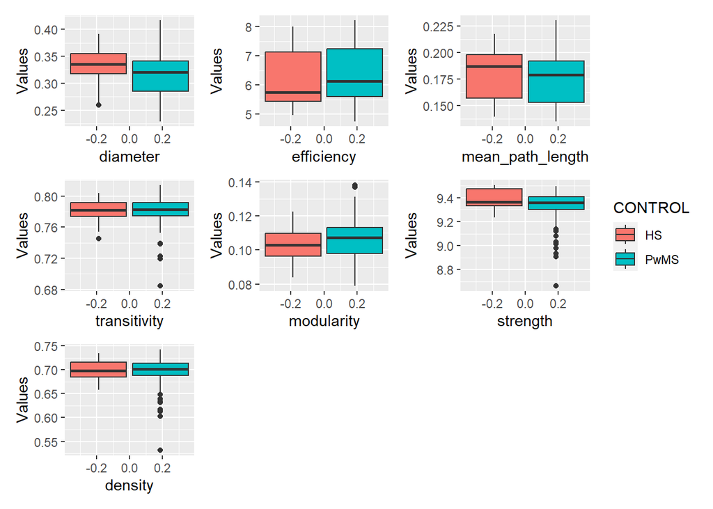

```r
cols_measures <-  c("controls", "diameter", "efficiency", "mean_path_length", "transitivity", "modularity", "strength", "density" )

df <- clinical_data[, grepl("FA_", names(clinical_data))]

df <- cbind(clinical_data$controls_ms, df)
colnames(df) <- cols_measures

individual_boxplot <- function(df, column_name){

  p <- df %>% ggplot(aes(y = df[, c(column_name)] , fill =  controls))+
  geom_boxplot()+
  xlab(column_name)+
  ylab("Values")+
  scale_fill_discrete(name = "CONTROL", labels = c("HS", "PwMS"))
  return(p)
}
p1 <- individual_boxplot(df, "diameter")
p2 <- individual_boxplot(df, "efficiency")
p3 <- individual_boxplot(df, "mean_path_length")
p4 <- individual_boxplot(df, "transitivity")
p5 <- individual_boxplot(df, "modularity")
p6 <- individual_boxplot(df, "strength")
p7 <- individual_boxplot(df, "density")

p <- p1 + p2 + p3 + p4 +p5 + p6 +p7 +
  plot_layout(ncol = 3, nrow = 3, guides = "collect")

ggsave(filename = "images/FA_single_layers_boxplot.png", plot = p, width = 10, height = 7, dpi = 300)
p
```

If we compare this case to the non-normalized one, we can appreciate differences between the two cases are minimal in most measurements.

## GM

GM layer has one prominent outlier. All data has the same value for density (1.0), modularity (0.0) and transitivity(1.0), so we impute the values that all the res present.

In the case of efficency it present a very different value from the rest. In this case we impute the mean of the rest of values.

```r
idx_outlier <- which(clinical_data$`GM_gl-transitivity`<1)

clinical_data$GM_density[idx_outlier] <- 1.0
clinical_data$`GM_gl-modularity`[idx_outlier] <- 0.0
clinical_data$`GM_gl-transitivity`[idx_outlier] <- 1.0

efficiency_vector <- clinical_data$`GM_gl-efficiency`[-idx_outlier] #We take values, except the otlier
clinical_data$`GM_gl-efficiency`[idx_outlier] <- mean(efficiency_vector) # Impute the mean

clinical_data$`GM_gl-modularity`[abs(clinical_data$`GM_gl-modularity`) < 1e-10] <- 0.0
```

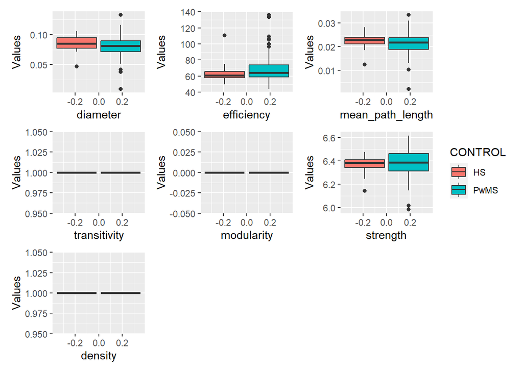

```r
df <- clinical_data[, grepl("GM_", names(clinical_data))]

df <- cbind(clinical_data$controls_ms, df)
colnames(df) <- cols_measures

p1 <- individual_boxplot(df, "diameter")
p2 <- individual_boxplot(df, "efficiency")
p3 <- individual_boxplot(df, "mean_path_length")
p4 <- individual_boxplot(df, "transitivity")
p5 <- individual_boxplot(df, "modularity")
p6 <- individual_boxplot(df, "strength")
p7 <- individual_boxplot(df, "density")

p <- p1 + p2 + p3 + p4 +p5 + p6 +p7 +
  plot_layout(ncol = 3, nrow = 3, guides = "collect")

ggsave(filename = "images/GM_single_layers_boxplot.png", plot = p, width = 10, height = 7, dpi = 300)
p
```

## fMRI

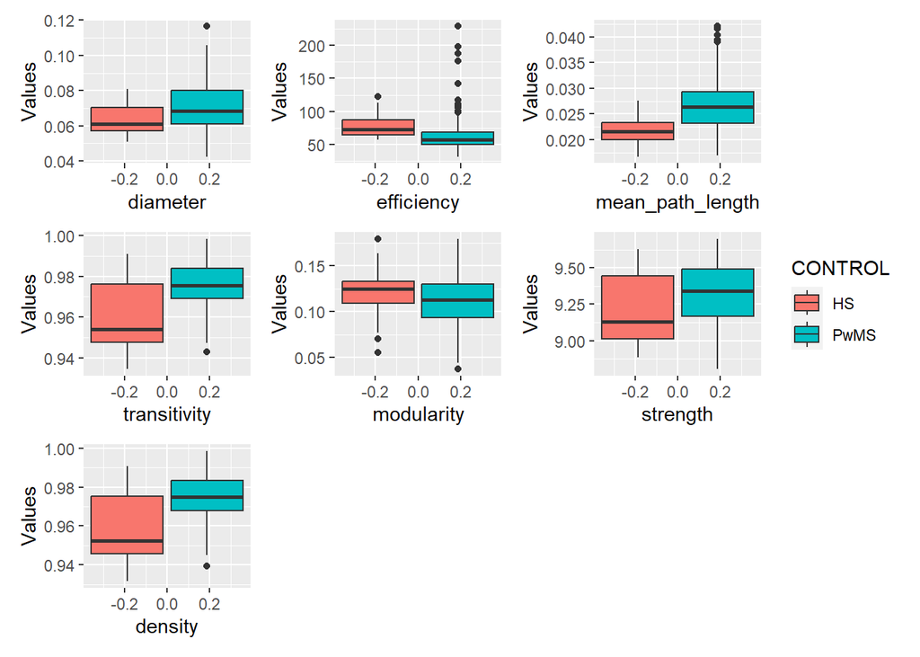

```r
df <- clinical_data[, grepl("fMRI_", names(clinical_data))]

df <- cbind(clinical_data$controls_ms, df)
colnames(df) <- cols_measures

p1 <- individual_boxplot(df, "diameter")
p2 <- individual_boxplot(df, "efficiency")
p3 <- individual_boxplot(df, "mean_path_length")
p4 <- individual_boxplot(df, "transitivity")
p5 <- individual_boxplot(df, "modularity")
p6 <- individual_boxplot(df, "strength")
p7 <- individual_boxplot(df, "density")

p <- p1 + p2 + p3 + p4 +p5 + p6 +p7 +
  plot_layout(ncol = 3, nrow = 3, guides = "collect")

ggsave(filename = "images/fMRI_single_layers_boxplot.png", plot = p, width = 10, height = 7, dpi = 300)
p
```

In this case, normalized and non normalized situations exhibit similar behaviour. It is worth noting that there seem to be more outliers (or at least more “extreme”) in graph efficiency

# Statistical measures

## Normality and Statistical difference

Before we assess the statistical differences in our measurements, it’s important to determine if the data distribution is normal. While we could use a QQ-plot for this purpose, due to the large number of variables (7 graph measures across 3 layers), we will utilize the Shapiro-Wilk test. Following this, we will examine whether there’s a statistically significant difference between groups. Depending on the normality of the variables, we will use either the t-test or the Mann-Whitney U test.

In this step we only use statistical differences between control and PwMS

```r
# Statistical test defined in helper_functions.R
vector_p <- c()
cols <- colnames(clinical_data[, c(27:47)])

for(col in cols){
  res <- statistical_test(clinical_data, col)
  vector_p <- c(vector_p, res)
}

vector_p[is.nan(vector_p)] <- 1.0

df_summary$p.value <- vector_p
stat_cols <- df_summary$measurement[df_summary$p.value < 0.05]
cat(paste("We have", length(stat_cols),"measures that show statistically significant differences" ))
```

```
## We have 6 measures that show statistically significant differences
```

```r
cat("\n")
```

```r
cat("\n")
```

```r
print(stat_cols)
```

```
## [1] "FA_diameter"           "fMRI_diameter"         "fMRI_gl-efficiency"
## [4] "fMRI_mean_path-length" "fMRI_gl-transitivity"  "fMRI_density"
```

In this normalized case, we have different fewer of statistically different measurements, and one measure (diameter of fMRI layer) is not present in the most populated case of non-normalized graphs. It is worth noting that only one global measure in the list is from FA layer. We also do not have any measurement from GM layer as in the non-normalized case.

We have all our stats in 1 dataframe

```r
head(df_summary)
```

```
##           measurement   Mean_HS      sd_HS Mean_PWMS    sd_PWMS    p.value
## 1         FA_diameter 0.3322241 0.03432373 0.3141971 0.03636324 0.04072495
## 2    FA_gl-efficiency 6.2664203 0.99438707 6.4091196 0.92026621 0.28747915
## 3 FA_mean_path-length 0.1782653 0.02398921 0.1736762 0.02271106 0.25125854
## 4  FA_gl-transitivity 0.7794781 0.01581929 0.7811264 0.01746537 0.60301234
## 5    FA_gl-modularity 0.1029154 0.01022693 0.1063821 0.01175959 0.23350697
## 6      FA_gl-strength 9.3881554 0.08038648 9.3312506 0.12441141 0.14261099
```

Now, we examine correlations between the mesurements that have passed the test

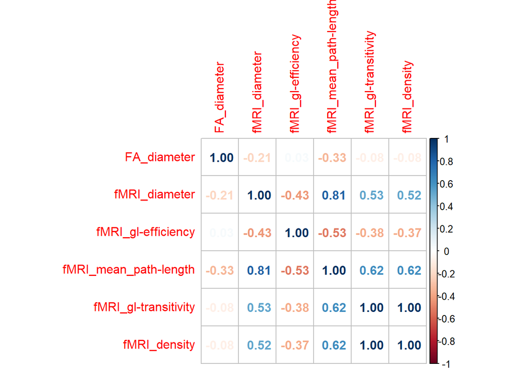

```r
correlations <- clinical_data %>% select(all_of(stat_cols)) %>% cor()

corrplot::corrplot(correlations, method = 'number')
```

*save image*

```r
png("images/corr_single_layers_global.png")
corrplot::corrplot(correlations, method = 'number', tl.col = "black")
dev.off()
```

## Pairwise t test using Bonferroni

In our clinical data, PwMS are categorized into multiple groups (mstype). In this scenario, we can use the t-test with Bonferroni correction to determine if any of the measures also exhibit differences.

We will exclusively examine differences between MS types, excluding HS from this analysis, as we will only examine columns that demonstrate statistical differences

```r
#We apply Bonferroni correction to each column

pairwise_t_tests_list <- lapply(stat_cols, function(x) {
  pairwise.t.test(clinical_data[[x]], clinical_data$mstype, p.adjust.method = "bonferroni")
})

stat_cols_2 <- c()
for(i in seq_along(stat_cols)){
  p_values <- pairwise_t_tests_list[[i]]$p.value
  if(p_values[5] < 0.05 | p_values[6] < 0.05 | p_values[9] < 0.05){ #Only check differences between mstypes
    stat_cols_2 <- c(stat_cols_2, stat_cols[i])
  }
}

cat(paste("We have", length(stat_cols_2),"measures that show statistically significant differences between types" ))
```

```
## We have 1 measures that show statistically significant differences between types
```

```r
cat("\n")
```

```r
cat("\n")
```

```r
print(stat_cols_2)
```

```
## [1] "FA_diameter"
```

Only one measure passes this test. Interestingly is the only one we had from the FA layer

# Local measures

Local measures we are performing are:

1. Efficiency
2. Closeness Centrality
3. Strength

(Clustering —> We do not apply this because none passes the statistical test)

It may seem that there are less measurements than in global case, but it is important to remember we will have each measurement for all 76 nodes. Se we will have 76 nodes x 3 measurments x 3 layers

```r
#We strore data in an specific dataframe
cli_data_loc <- clinical_data[, c("controls_ms", "mstype")]

cli_data_loc <-add_local_graph_measures(cli_data_loc, FA_graphs, "FA")
cli_data_loc <-add_local_graph_measures(cli_data_loc, GM_graphs, "GM")
cli_data_loc <-add_local_graph_measures(cli_data_loc, fMRI_graphs, "fMRI")
```

Summarise values

```r
#Preserve only numerical values
df_temp <- cli_data_loc
df_temp$mstype <- NULL

df_summary_loc <- data.frame(measurement = character(0),
                          Mean_HS = numeric(0),
                         sd_HS = numeric(0),
                         Mean_PWMS = numeric(0),
                         sd_PWMS = numeric(0))

for(i in 2:ncol(df_temp)){
  measurement <- colnames(df_temp)[i]
  Mean_HS <- mean(df_temp[df_temp$controls_ms == "HS", i])
  sd_HS <- sd(df_temp[df_temp$controls_ms == "HS", i])

  Mean_PWMS <- mean(df_temp[df_temp$controls_ms == "PwMS", i])
  sd_PWMS <- sd(df_temp[df_temp$controls_ms == "PwMS", i])

  df_summary_loc <- rbind( df_summary_loc, data.frame(measurement = measurement,
                                              Mean_HS = Mean_HS,
                                              sd_HS = sd_HS,
                                              Mean_PWMS = Mean_PWMS,
                                              sd_PWMS = sd_PWMS))


}
```

## STATISTICAL MEASURES

We proceed as we did before

```r
vector_p <- c()
cols <- colnames(cli_data_loc[, c(3:ncol(cli_data_loc))])

for(col in cols){
  res <- statistical_test(cli_data_loc, col)
  vector_p <- c(vector_p, res)
}


df_summary_loc$p.value <- vector_p
stat_cols_loc <- df_summary_loc$measurement[df_summary_loc$p.value < 0.05]


cat(paste("We have", length(stat_cols_loc),"measures that show statistically significant differences between types" ))
```

```
## We have 191 measures that show statistically significant differences between types
```

```r
cat("\n")
```

```r
cat("\n")
```

```r
#We apply Bonferroni correction to each column

pairwise_t_tests_list <- lapply(stat_cols_loc, function(x) {
  pairwise.t.test(cli_data_loc[[x]], cli_data_loc$mstype, p.adjust.method = "bonferroni")
})

stat_cols_loc_2 <- c()
for(i in seq_along(stat_cols_loc)){
  p_values <- pairwise_t_tests_list[[i]]$p.value
  if(p_values[5] < 0.05 | p_values[6] < 0.05 | p_values[9] < 0.05){
    stat_cols_loc_2 <- c(stat_cols_loc_2, stat_cols_loc[i])
  }
}

cat(paste("We have", length(stat_cols_loc_2),"measures that show statistically significant differences between types" ))
```

```
## We have 9 measures that show statistically significant differences between types
```

```r
cat("\n")
```

```r
cat("\n")
```

```r
print(stat_cols_loc_2)
```

```
## [1] "FA_loc-clos-cent_ctx-lh-isthmuscingulate"
## [2] "FA_loc-clos-cent_Left-Hippocampus"
## [3] "FA_loc-clos-cent_ctx-rh-caudalanteriorcingulate"
## [4] "FA_loc-clos-cent_ctx-rh-lateralorbitofrontal"
## [5] "FA_loc-clos-cent_ctx-rh-precentral"
## [6] "FA_loc-strength_Right-Caudate"
## [7] "fMRI_loc-clos-cent_ctx-rh-entorhinal"
## [8] "fMRI_loc-clos-cent_ctx-rh-parahippocampal"
## [9] "fMRI_loc-clos-cent_ctx-rh-paracentral"
```

In non-normalized case we had almost 100 local graph measures that passed both statistical tests, but in this case we have a very limited number and almost all of the measures come from closeness centrality. Regarding the layers we have 6 measurements from FA layer and 3 from fMRI

## How many of each layer, how many of each measure and how many of each node

```r
split_names <- lapply(stat_cols_loc_2, function(x) strsplit(x, split = "_")[[1]])

# Store each part in a separate vector
layer_vector <- sapply(split_names, `[[`, 1)
measure_vector <- sapply(split_names, `[[`, 2)
node_vector <- sapply(split_names, `[[`, 3)


table(layer_vector)
```

```
## layer_vector
##   FA fMRI
##    6    3
```

```r
table(measure_vector)
```

```
## measure_vector
## loc-clos-cent  loc-strength
##             8             1
```

```r
#head(sort(table(node_vector), decreasing = TRUE), n = 25)
```

# Final dataframe

```r
#df_glob <- clinical_data[ , stat_cols]
#df_loc <- cli_data_loc[, stat_cols_loc_2]
#single_layer_df <- clinical_data[, c("id", "control_ms", "mstype", "age", "sex", "dd", "edss")]
single_layer_df <- bind_cols(clinical_data[, c("id", "controls_ms", "mstype", "age", "sex", "dd", "edss")],
                             clinical_data[ , stat_cols],
                             cli_data_loc[, stat_cols_loc_2])
```

```r
write.table(single_layer_df, file = file.path(dataDIR, "single_layer.csv"), sep = ",", quote = FALSE, row.names = FALSE )
```

## SAVE SUMMARY TO EXCEL

```r
wb <- openxlsx::createWorkbook()

openxlsx::addWorksheet(wb, "Gl_summary")
openxlsx::writeData(wb, "Gl_summary", df_summary)

openxlsx::addWorksheet(wb, "loc_summary")
openxlsx::writeData(wb, "loc_summary", df_summary_loc)

openxlsx::saveWorkbook(wb, file = paste0(dataDIR, "summary_single_layers.xlsx"), overwrite = TRUE)
```